# Praca domowa nr 5 Marika Partyka 14.04.2020

## Wstęp - model i dane

Do 4 pracy domowej użyłam zbioru danych z wcześniejszych prac domowych, czyli **muschrooms**. Jest to problem klasyfikacji binarnej, w której przewidujemy, czy dany grzyb będzie jadalny czy nie. Pierwszy model to RandomForest. Wszystkie zmienne to zmienne kategoryczne, na których zastosowano transformacje *one hot encoding*.

Po takich transformacjach kolumn okazuje się, że model przewiduje w zasadzie bezbłędnie do jakiej klasy należy dany grzyb. Przedstawia to poniższa krzywa ROC.

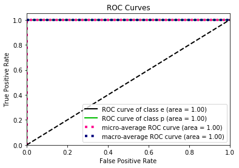

```python
skplt.metrics.plot_roc(y_true, y_probas)
plt.show()
```

# Variable Importance - RandomForest

Zobaczmy jak wygląda istotność zmiennych przy modelu Random Forest

```python
virf.plot(max_vars=10)
```

[interactive chart not shown]

Potwierdziły się przypuszczenia z poprzednich prac domowych, a mianowicie to, że zmienna **odor** jest zmienną, która najbardziej wpływa na wynik predykcji. Na powyższym wykresie widać **10** najważniejszych zmiennych spośród 22.

# Variable Importance - Logistic Regression

Teraz zmienimy model, ale kodowanie zmiennych i ilość predyktorów pozostaje taka sama.

```python
vilr.plot(max_vars=10)
```

[interactive chart not shown]

W tym przypadku pierwsze 3 najważniejsze zmienne są takie same jak dla poprzedniego modelu. To co można jeszcze zauważyć to to, że w modelu RandomForest ważność zmienych spada umiarkowanie i spadek jest rozłożony równomiernie w miarę przechodzenia do kolejnych zmiennych, natomiast w LogisticRegression zmienna **odor** jest zdecydowanie na prowadzeniu względem reszty zmiennych.

# Selekcja zmiennych

Wybierzemy teraz **10** najważniejszych zmiennych, które wskazał model RandomForest i na takim zbiorze danych zbudujemy inne modele.

## Variable Importance - DecisionTree

```python
vidt.plot(max_vars=10)
```

[interactive chart not shown]

## Variable Importance - K-NN

```python
vikn.plot(max_vars=10)
```

[interactive chart not shown]

## Variable Importance - SVM

```python
visv.plot(max_vars=10)
```

[interactive chart not shown]

Porównując powyższe 3 wydruki widzimy, że kolejne modele uznały zmienną **odor** za najważniejszą. Największą wagę przypisał jej model K - Najbliższych Sąsiadów. Sporą różnice można zauważyć przy zmiennej **gill-size**. Modele: SVM oraz Drzewo Decyzyjne uznały tę zmienną za drugą pod wględem ważności, natomiast model K-NN ustawił ją na 7 miejscu. Dodatkowo widać, że dwa z modeli- SVM oraz DT wybrało tylko kilka spośród 10 jako ważne - odpowiednio 7 i 6.

## Załącznik

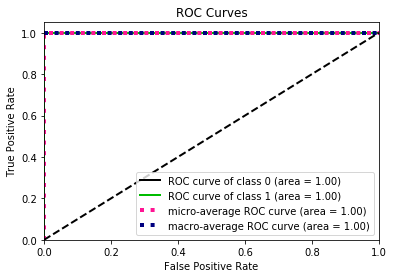

```
Preparation of a new explainer is initiated

  -> target variable   :  Mushrooms Random Forest
  -> data              : 6499 rows 22 cols
  -> target variable   : 6499 values
  -> predict function  : <function yhat.<locals>.<lambda> at 0x7fda06e57320> will be used
  -> predicted values  : min = 0.0, mean = 0.5193445145406986, max = 1.0
  -> residual function : difference between y and yhat
  -> residuals         : min = -0.1, mean = -3.3851361747961195e-05, max = 0.050000000000000044
  -> model_info        : package sklearn

A new explainer has been created!
```

[interactive chart not shown]

```
Preparation of a new explainer is initiated

  -> target variable   :  Mushrooms Logistic Regression
  -> data              : 6499 rows 22 cols
  -> target variable   : 6499 values
  -> predict function  : <function yhat.<locals>.<lambda> at 0x7fda05d45830> will be used
  -> predicted values  : min = 8.504091992748883e-06, mean = 0.5193106798300666, max = 0.9999930474139184
  -> residual function : difference between y and yhat
  -> residuals         : min = -0.4838268373660537, mean = -1.6651115968240823e-08, max = 0.15967652142793443
  -> model_info        : package sklearn

A new explainer has been created!
```

[interactive chart not shown]

```
Preparation of a new explainer is initiated

  -> target variable   :  Mushrooms Decision Tree
  -> data              : 6499 rows 10 cols
  -> target variable   : 6499 values
  -> predict function  : <function yhat.<locals>.<lambda> at 0x7fda059c5b90> will be used
  -> predicted values  : min = 0.0, mean = 0.5211571010924758, max = 1.0
  -> residual function : difference between y and yhat
  -> residuals         : min = 0.0, mean = 0.0, max = 0.0
  -> model_info        : package sklearn

A new explainer has been created!
```

[interactive chart not shown]

```
Preparation of a new explainer is initiated

  -> target variable   :  Mushrooms K-NN
  -> data              : 6499 rows 10 cols
  -> target variable   : 6499 values
  -> predict function  : <function yhat.<locals>.<lambda> at 0x7fda059c5e60> will be used
  -> predicted values  : min = 0.0, mean = 0.5211571010924758, max = 1.0
  -> residual function : difference between y and yhat
  -> residuals         : min = 0.0, mean = 0.0, max = 0.0
  -> model_info        : package sklearn

A new explainer has been created!
```

[interactive chart not shown]

```
Preparation of a new explainer is initiated

  -> target variable   :  Mushrooms SVM
  -> data              : 6499 rows 10 cols
  -> target variable   : 6499 values
  -> predict function  : <function yhat.<locals>.<lambda> at 0x7fda059c5b00> will be used
  -> predicted values  : min = 0, mean = 0.5211571010924758, max = 1
  -> residual function : difference between y and yhat
  -> residuals         : min = 0, mean = 0.0, max = 0
  -> model_info        : package sklearn

A new explainer has been created!
```

[interactive chart not shown]

```python
import pandas as pd
import numpy as np
from sklearn.model_selection import train_test_split
import random
from sklearn.pipeline import Pipeline
from sklearn.preprocessing import OneHotEncoder
from sklearn.ensemble import RandomForestClassifier
from sklearn.ensemble import GradientBoostingClassifier
from sklearn.linear_model import LogisticRegression
import dalex as dx
%matplotlib inline

random.seed(123)

df = pd.read_csv("/home/user/Pobrane/mushroom-classification/mushrooms.csv")
y = df['class']
y = np.where(y=='e', 1, 0)
X = df.drop(["class"], inplace = False, axis = 1)
X_train, X_test, y_train, y_test = train_test_split(X, y,
    test_size=0.2)
rfc = Pipeline(steps=[("preprocessor", OneHotEncoder()),("classifier", RandomForestClassifier())])
rfc.fit(X_train, y_train)


lrc = Pipeline(steps=[("preprocessor", OneHotEncoder()),("classifier", LogisticRegression())])
lrc.fit(X_train, y_train)
import scikitplot as skplt
import matplotlib.pyplot as plt

y_true = y_test
y_probas_rfc = rfc.predict_proba(X_test)
# y_probas_rgb = rgb.predict_proba(X_test)

skplt.metrics.plot_roc_curve(y_true, y_probas_rfc)
plt.show()
exprf = dx.Explainer(rfc, X_train, y_train, label = "Mushrooms Random Forest")
virf = exprf.model_parts()
virf.plot(max_vars=10)

explr = dx.Explainer(lrc, X_train, y_train, label = "Mushrooms Logistic Regression")
vilr = explr.model_parts()
vilr.plot(max_vars=10)
# lrc = Pipeline(steps=[("preprocessor", OneHotEncoder()),("classifier", LogisticRegression())])
# lrc.fit(X_train, y_train)
X_new = X.loc[:,["odor", "gill-size", "spore-print-color", "ring-type","stalk-surface-above-ring",
                   "stalk-root","gill-color","bruises","gill-spacing", "stalk-shape"]]

X_train, X_test, y_train, y_test = train_test_split(X_new, y,
    test_size=0.2)
from sklearn.tree import DecisionTreeClassifier
dtc =  Pipeline(steps=[("preprocessor", OneHotEncoder()),("classifier", DecisionTreeClassifier())])
dtc.fit(X_train, y_train)

expdt = dx.Explainer(dtc, X_train, y_train, label = "Mushrooms Decision Tree")
vidt = expdt.model_parts()
vidt.plot(max_vars=10)


from sklearn.neighbors import KNeighborsClassifier
knc =  Pipeline(steps=[("preprocessor", OneHotEncoder()),("classifier", KNeighborsClassifier())])
knc.fit(X_train, y_train)

expkn = dx.Explainer(knc, X_train, y_train, label = "Mushrooms K-NN")
vikn = expkn.model_parts()
vikn.plot(max_vars=10)


from sklearn.svm import SVC


svmc =  Pipeline(steps=[("preprocessor", OneHotEncoder()),("classifier", SVC())])
svmc.fit(X_train, y_train)
expsv = dx.Explainer(svmc, X_train, y_train, label = "Mushrooms SVM")
visv = expsv.model_parts()
visv.plot(max_vars=10)
```